# PHW251: Midterm Live Session

Lyndsay Miles

2023-10-12

We will be using data from the Tidy Tuesday project. Tidy Tuesday is a weekly social data project available for free online. They have a goal of “making learning to work with data easier” and are a great resource for interesting data sets. To learn more about this project and explore the many data sets they have available, go to https://github.com/rfordatascience/tidytuesday.

For these practice problems, we will be using the “bob_ross” data set, which is a data set of all of the paintings painted on Bob Ross’s TV show, “The Joy of Painting.” A full data dictionary is available at the source website (https://github.com/rfordatascience/tidytuesday/tree/master/data/2023/2023-02-21). For our purposes, we are interested in the following variables:

| Variable | Description |
| --- | --- |
| painting index | Painting number as enumerated in collection. |
| painting title | Title of the painting. |
| Season | Season of ‘The Joy of Painting’ in which the painting was featured. |
| Episode | Episode of ‘The Joy of Painting’ in which the painting was featured. |
| num_colors | Number of unique colors used in the painting. |
| colors | List of colors used in the painting. |
| Cadmium_Yellow | Cadmium_Yellow used |

1. First, read in the file provided, “bob_ross.csv”.

```r
#read in file
#data comes from tidy tuesday (https://github.com/rfordatascience/tidytuesday/tree/master/data/2023/2023-02-21).

#YOUR CODE HERE

#ANSWERS
bob_ross <- read_csv("bob_ross.csv")
```

2. Use functions you learned in Week 3 to investigate what kind of data you have here. What functions would you use to do this? Information you might want to know is: how many observations are there? how many variables? what kind of data?

```
## [1] 403  27
```

```
## spc_tbl_ [403 × 27] (S3: spec_tbl_df/tbl_df/tbl/data.frame)
##  $ painting index  : num [1:403] 282 283 284 285 286 287 288 289 290 291 ...
##  $ img src         : chr [1:403] "https://www.twoinchbrush.com/images/painting282.png" "https://www.twoinchbrush.com/images/painting283.png" "https://www.twoinchbrush.com/images/painting284.png" "https://www.twoinchbrush.com/images/painting285.png" ...
##  $ painting title  : chr [1:403] "A Walk in the Woods" "Mt. McKinley" "Ebony Sunset" "Winter Mist" ...
##  $ Season          : num [1:403] 1 1 1 1 1 1 1 1 1 1 ...
##  $ Episode         : num [1:403] 1 2 3 4 5 6 7 8 9 10 ...
##  $ num_colors      : num [1:403] 8 8 9 3 8 4 8 8 8 8 ...
##  $ youtube_src     : chr [1:403] "https://www.youtube.com/embed/oh5p5f5_-7A" "https://www.youtube.com/embed/RInDWhYceLU" "https://www.youtube.com/embed/UOziR7PoVco" "https://www.youtube.com/embed/0pwoixRikn4" ...
##  $ colors          : chr [1:403] "['Alizarin Crimson', 'Bright Red', 'Cadmium Yellow', 'Phthalo Green\\r\\n', 'Prussian Blue', 'Sap Green', 'Tita"| __truncated__ "['Alizarin Crimson', 'Bright Red', 'Cadmium Yellow', 'Phthalo Green\\r\\n', 'Prussian Blue', 'Sap Green', 'Tita"| __truncated__ "['Ali…
##  $ color_hex       : chr [1:403] "['#4E1500', '#DB0000', '#FFEC00', '#102E3C', '#021E44', '#0A3410', '#FFFFFF', '#221B15']" "['#4E1500', '#DB0000', '#FFEC00', '#102E3C', '#021E44', '#0A3410', '#FFFFFF', '#221B15']" "['#4E1500', '#000000', '#DB0000', '#FFEC00', '#102E3C', '#021E44', '#0A3410', '#F…
##  $ Black_Gesso     : logi [1:403] FALSE FALSE TRUE FALSE FALSE TRUE ...
##  $ Bright_Red      : logi [1:403] TRUE TRUE TRUE FALSE TRUE FALSE ...
##  $ Burnt_Umber     : logi [1:403] FALSE FALSE FALSE FALSE FALSE FALSE ...
##  $ Cadmium_Yellow  : logi [1:403] TRUE TRUE TRUE FALSE TRUE FALSE ...
##  $ Dark_Sienna     : logi [1:403] FALSE FALSE FALSE FALSE FALSE FALSE ...
##  $ Indian_Red      : logi [1:403] FALSE FALSE FALSE FALSE FALSE FALSE ...
##  $ Indian_Yellow   : logi [1:403] FALSE FALSE FALSE FALSE FALSE FALSE ...
##  $ Liquid_Black    : logi [1:403] FALSE FALSE FALSE FALSE FALSE FALSE ...
##  $ Liquid_Clear    : logi [1:403] FALSE FALSE FALSE FALSE FALSE FALSE ...
##  $ Midnight_Black  : logi [1:403] FALSE FALSE FALSE FALSE FALSE FALSE ...
##  $ Phthalo_Blue    : logi [1:403] FALSE FALSE FALSE FALSE FALSE FALSE ...
##  $ Phthalo_Green   : logi [1:403] TRUE TRUE TRUE FALSE TRUE FALSE ...
##  $ Prussian_Blue   : logi [1:403] TRUE TRUE TRUE TRUE TRUE TRUE ...
##  $ Sap_Green       : logi [1:403] TRUE TRUE TRUE FALSE TRUE FALSE ...
##  $ Titanium_White  : logi [1:403] TRUE TRUE TRUE TRUE TRUE TRUE ...
##  $ Van_Dyke_Brown  : logi [1:403] TRUE TRUE TRUE TRUE TRUE TRUE ...
##  $ Yellow_Ochre    : logi [1:403] FALSE FALSE FALSE FALSE FALSE FALSE ...
##  $ Alizarin_Crimson: logi [1:403] TRUE TRUE TRUE FALSE TRUE FALSE ...
##  - attr(*, "spec")=
##   .. cols(
##   ..   `painting index` = col_double(),
##   ..   `img src` = col_character(),
##   ..   `painting title` = col_character(),
##   ..   Season = col_double(),
##   ..   Episode = col_double(),
##   ..   num_colors = col_double(),
##   ..   youtube_src = col_character(),
##   ..   colors = col_character(),
##   ..   color_hex = col_character(),
##   ..   Black_Gesso = col_logical(),
##   ..   Bright_Red = col_logical(),
##   ..   Burnt_Umber = col_logical(),
##   ..   Cadmium_Yellow = col_logical(),
##   ..   Dark_Sienna = col_logical(),
##   ..   Indian_Red = col_logical(),
##   ..   Indian_Yellow = col_logical(),
##   ..   Liquid_Black = col_logical(),
##   ..   Liquid_Clear = col_logical(),
##   ..   Midnight_Black = col_logical(),
##   ..   Phthalo_Blue = col_logical(),
##   ..   Phthalo_Green = col_logical(),
##   ..   Prussian_Blue = col_logical(),
##   ..   Sap_Green = col_logical(),
##   ..   Titanium_White = col_logical(),
##   ..   Van_Dyke_Brown = col_logical(),
##   ..   Yellow_Ochre = col_logical(),
##   ..   Alizarin_Crimson = col_logical()
##   .. )
##  - attr(*, "problems")=<externalptr>
```

```
## Rows: 403
## Columns: 27
## $ `painting index` <dbl> 282, 283, 284, 285, 286, 287, 288, 289, 290, 291, 292…
## $ `img src`        <chr> "https://www.twoinchbrush.com/images/painting282.png"…
## $ `painting title` <chr> "A Walk in the Woods", "Mt. McKinley", "Ebony Sunset"…
## $ Season           <dbl> 1, 1, 1, 1, 1, 1, 1, 1, 1, 1, 1, 1, 1, 2, 2, 2, 2, 2,…
## $ Episode          <dbl> 1, 2, 3, 4, 5, 6, 7, 8, 9, 10, 11, 12, 13, 1, 2, 3, 4…
## $ num_colors       <dbl> 8, 8, 9, 3, 8, 4, 8, 8, 8, 8, 8, 4, 8, 12, 12, 13, 3,…
## $ youtube_src      <chr> "https://www.youtube.com/embed/oh5p5f5_-7A", "https:/…
## $ colors           <chr> "['Alizarin Crimson', 'Bright Red', 'Cadmium Yellow',…
## $ color_hex        <chr> "['#4E1500', '#DB0000', '#FFEC00', '#102E3C', '#021E4…
## $ Black_Gesso      <lgl> FALSE, FALSE, TRUE, FALSE, FALSE, TRUE, FALSE, FALSE,…
## $ Bright_Red       <lgl> TRUE, TRUE, TRUE, FALSE, TRUE, FALSE, TRUE, TRUE, TRU…
## $ Burnt_Umber      <lgl> FALSE, FALSE, FALSE, FALSE, FALSE, FALSE, FALSE, FALS…
## $ Cadmium_Yellow   <lgl> TRUE, TRUE, TRUE, FALSE, TRUE, FALSE, TRUE, TRUE, TRU…
## $ Dark_Sienna      <lgl> FALSE, FALSE, FALSE, FALSE, FALSE, FALSE, FALSE, FALS…
## $ Indian_Red       <lgl> FALSE, FALSE, FALSE, FALSE, FALSE, FALSE, FALSE, FALS…
## $ Indian_Yellow    <lgl> FALSE, FALSE, FALSE, FALSE, FALSE, FALSE, FALSE, FALS…
## $ Liquid_Black     <lgl> FALSE, FALSE, FALSE, FALSE, FALSE, FALSE, FALSE, FALS…
## $ Liquid_Clear     <lgl> FALSE, FALSE, FALSE, FALSE, FALSE, FALSE, FALSE, FALS…
## $ Midnight_Black   <lgl> FALSE, FALSE, FALSE, FALSE, FALSE, FALSE, FALSE, FALS…
## $ Phthalo_Blue     <lgl> FALSE, FALSE, FALSE, FALSE, FALSE, FALSE, FALSE, FALS…
## $ Phthalo_Green    <lgl> TRUE, TRUE, TRUE, FALSE, TRUE, FALSE, TRUE, TRUE, TRU…
## $ Prussian_Blue    <lgl> TRUE, TRUE, TRUE, TRUE, TRUE, TRUE, TRUE, TRUE, TRUE,…
## $ Sap_Green        <lgl> TRUE, TRUE, TRUE, FALSE, TRUE, FALSE, TRUE, TRUE, TRU…
## $ Titanium_White   <lgl> TRUE, TRUE, TRUE, TRUE, TRUE, TRUE, TRUE, TRUE, TRUE,…
## $ Van_Dyke_Brown   <lgl> TRUE, TRUE, TRUE, TRUE, TRUE, TRUE, TRUE, TRUE, TRUE,…
## $ Yellow_Ochre     <lgl> FALSE, FALSE, FALSE, FALSE, FALSE, FALSE, FALSE, FALS…
## $ Alizarin_Crimson <lgl> TRUE, TRUE, TRUE, FALSE, TRUE, FALSE, TRUE, TRUE, TRU…
```

3. The column names could be more reader-friendly; their current format is not very ‘tidy’.
   1. Rename the column names so that all names are lowercase and snake case.
   2. Use R to create an output displaying the new names.

```r
#YOUR CODE HERE

#ANSWERS
bob_ross <- bob_ross %>%
  rename_with(~ tolower(gsub(" ","_",.x,fixed=TRUE)))

names(bob_ross)
```

```
##  [1] "painting_index"   "img_src"          "painting_title"   "season"
##  [5] "episode"          "num_colors"       "youtube_src"      "colors"
##  [9] "color_hex"        "black_gesso"      "bright_red"       "burnt_umber"
## [13] "cadmium_yellow"   "dark_sienna"      "indian_red"       "indian_yellow"
## [17] "liquid_black"     "liquid_clear"     "midnight_black"   "phthalo_blue"
## [21] "phthalo_green"    "prussian_blue"    "sap_green"        "titanium_white"
## [25] "van_dyke_brown"   "yellow_ochre"     "alizarin_crimson"
```

4. There are a lot of variables here and we just want to focus on a few of them.
   1. Create a new data frame called bob_ross_abbr that includes only the following variables:
   - painting_title
   - season
   - episode
   - num_colors
   - colors
   2. Save the data frame as a tibble.

```r
#YOUR CODE HERE

#ANSWERS
bob_ross_abbr <- bob_ross %>%
  select(painting_title, season, episode, num_colors, colors)

as_tibble(bob_ross_abbr)
```

```
## # A tibble: 403 × 5
##    painting_title      season episode num_colors colors
##    <chr>                <dbl>   <dbl>      <dbl> <chr>
##  1 A Walk in the Woods      1       1          8 "['Alizarin Crimson', 'Bright …
##  2 Mt. McKinley             1       2          8 "['Alizarin Crimson', 'Bright …
##  3 Ebony Sunset             1       3          9 "['Alizarin Crimson', 'Black G…
##  4 Winter Mist              1       4          3 "['Prussian Blue', 'Titanium W…
##  5 Quiet Stream             1       5          8 "['Alizarin Crimson', 'Bright …
##  6 Winter Moon              1       6          4 "['Black Gesso', 'Prussian Blu…
##  7 Autumn Mountain          1       7          8 "['Alizarin Crimson', 'Bright …
##  8 Peaceful Valley          1       8          8 "['Alizarin Crimson', 'Bright …
##  9 Seascape                 1       9          8 "['Alizarin Crimson', 'Bright …
## 10 Mountain Lake            1      10          8 "['Alizarin Crimson', 'Bright …
## # ℹ 393 more rows
```

5. You want to categorize the number of colors used for each painting in the bob_ross_abbr data frame.
   1. Use a case_when() statement to add a new variable “color_cat” that categorizes a painting based on the number of colors (num_colors) used.
   2. Categorize as follows: “low” if 2-5 used, “medium” if 6-8 colors used, and “high” if 9 or more colors used. Any cases with just one color of paint should be categorized as “outlier”.
   3. Arrange the observations by num_colors in ascending order before taking a look at bob_ross_abbr again.

```r
#YOUR CODE HERE

#ANSWERS
bob_ross_abbr <- bob_ross_abbr %>%
  mutate(color_cat = case_when(num_colors >=2 & num_colors< 6 ~ "low",
                               num_colors >=6 & num_colors<9 ~ "medium",
                               num_colors >=9 ~ "high",
                               TRUE ~ "outlier"

  )) %>%
  arrange(num_colors)
head(bob_ross_abbr)
```

```
## # A tibble: 6 × 6
##   painting_title     season episode num_colors colors                  color_cat
##   <chr>               <dbl>   <dbl>      <dbl> <chr>                   <chr>
## 1 Contemplative Lady     16       6          1 "['Van Dyke Brown']"    outlier
## 2 Winter Mist             1       4          3 "['Prussian Blue', 'Ti… low
## 3 Shades of Grey          2       4          3 "['Prussian Blue', 'Ti… low
## 4 Grey Winter             7      11          3 "['Alizarin Crimson', … low
## 5 Blue Winter            21      10          3 "['Midnight Black\\r\\… low
## 6 Winter Moon             1       6          4 "['Black Gesso', 'Prus… low
```

6. Could you have completed the task in the question above with an if_else() statement? Why or why not? *YOUR ANSWER HERE*

#ANSWERS *Yes, you could have used nested if_else() statements to accomplish this. Using case_when() vs. using if_else() is a matter of your preference. However, using if_else() can be more cumbersome and more difficult to debug.*

7. With bob_ross_abbr, group by the variable, season, and then summarize to determine the average number of unique colors used per season. Save as a new data frame called bob_ross_colors.

```r
#YOUR CODE HERE

#ANSWERS
bob_ross_colors <- bob_ross_abbr %>%
  group_by(season) %>%
  summarize(avg_num_colors = mean(num_colors))
head(bob_ross_colors)
```

```
## # A tibble: 6 × 2
##   season avg_num_colors
##    <dbl>          <dbl>
## 1      1           7.08
## 2      2          11.2
## 3      3           9.85
## 4      4          10
## 5      5           8.54
## 6      6          10.5
```

8. Determine from the bob_ross_colors data frame which season Bob used the most unique colors on average. Save your answer to an object called “most_colorful_season”.

Challenge: How would you use R to print out the value for this object using base R code?

```r
#YOUR CODE HERE

#ANSWERS
most_colorful_season <- 14
#with base R
most_colorful_season <-
  bob_ross_colors[bob_ross_colors$avg_num_colors==max(bob_ross_colors$avg_num_colors),]$season
most_colorful_season
```

```
## [1] 14
```

9. Visualize what you learned in problems 7 & 8. Use the bob_ross_colors data frame to make a graph (e.g., line chart, scatterplot) showing how the average number of colors used may have changed over the seasons.

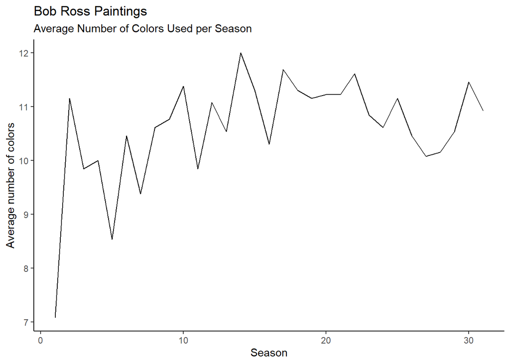

```r
#YOUR CODE HERE

#ANSWERS
ggplot(data = bob_ross_colors, aes(x=season, y=avg_num_colors))+
  geom_line()+
  labs(title="Bob Ross Paintings", subtitle = "Average Number of Colors Used per Season", x="Season", y="Average number of colors")+
  theme_classic()
```

10. You want to look closer at the names of the paintings from Season 1 only. Create a table using the kableExtra package that just displays the painting_title and episode number. Add a caption and column names that feel appropriate.

```r
#YOUR CODE HERE

#ANSWERS
library(kableExtra)
season_1 <- bob_ross_abbr %>%
  filter(season == 1) %>%
  select(painting_title, episode)%>%
  arrange(episode)


knitr:: kable(season_1,
              booktabs=TRUE,
              format="simple",
              caption = "Paintings from Season 1",
              col.names = c("Painting Title", "Episode #"))
```

Paintings from Season 1

| Painting Title | Episode # |
| --- | --- |
| A Walk in the Woods | 1 |
| Mt. McKinley | 2 |
| Ebony Sunset | 3 |
| Winter Mist | 4 |
| Quiet Stream | 5 |
| Winter Moon | 6 |
| Autumn Mountain | 7 |
| Peaceful Valley | 8 |
| Seascape | 9 |
| Mountain Lake | 10 |
| Winter Glow | 11 |
| Snow Fall | 12 |
| Final Reflections | 13 |